# 8_2_ARMA

# References:

1. Forecasting Principles and Practice - 3rd Edition (Rob J Hyndman and George Athanasopoulos) [Link](https://otexts.com/fpp3/)
2. Time Series: a data analysis approach using R - Shumwway-Stoffer - This book is a distilled version of reference 3. Still math intensive, yet much less challenging than reference 3. [Link](https://ie.on.worldcat.org/oclc/1101967011)
3. Time-Series Analysis and its Applications with R Examples - Shumway-Stoffer
4. Time Series Analysis: Forecasting and Control - 5th Edition - George E. P. Box, Gwilym M. Jenkins, Gregory C. Reinsel, Greta M. Ljung - this book is a very complete guide to ARIMA models. Yet very long.

(TODO: write references formally)

# Autorregressive models

In an autoregression model, the variable of interest is forecast using a **linear combination of past values of the variable**. The term **autoregression** indicates that **it is a regression of the variable against itself**.

These models are based on the idea that crrent values of the series depend on previous values of the same series.

An autoregressive model of **order p** $AR(p)$ has the form:

$$\begin{align*}
y_{t} = c + \phi_{1}y_{t-1} + \phi_{2}y_{t-2} + \dots + \phi_{p}y_{t-p} + \varepsilon_{t}
\end{align*}$$

- $\varepsilon_t$ is white noise
- $y_{t}$ is **stationary**

Shifting terms to the left and using backshift notation, we may express these model as:

$$y_t - \phi_1 y_{t-1} - \phi_2 y_{t-2} - \dots+ \phi_p y_{t-p} = c + \varepsilon_t$$

$$(1-\phi_1\,B-\phi_2\,B^2-\dots-\phi_p\,B^p)y_t = c + \varepsilon_t$$

$$\left(1-\sum_{i=1}^p\phi_iB^i\right)y_t = c+ \varepsilon_t$$

We will now further simplify the notation definint the **autoregressive operator**:

$$\phi(B)=1-\phi_1\,B-\phi_2\,B^2-\dots-\phi_p\,B^p = \left(1-\sum_{i=1}^p\phi_iB^i\right)$$

The model might be simply expressed as:

$$\phi(B)y_t=c+ \varepsilon_t$$

## Stationarity conditions of AR(p) models. Restrictions on the coefficients

Note that the model is a *regression of random components.* The predictors (the lagged values of $y_t$) are random, whereas in normal regression we assumed that the predictors were not random variables. This will give rise to some technical difficulties, **most notably the need to impose some restrictions on the parameters of the autoregressive model,** whereas no restrictions applied in normal regression.

These conditions are focused on **ensuring the resulting models represent stationary data**. Mathematically, they translate into ensuring that **the complex roots of the following polynomial lie outside the unit circle of the complex plane**. For the specific math behind is, the reader is referred to chapter 4 of reference [2] and chapter 3 of reference [3].

$$1 - \phi_1z-\phi_2z^2-\dots-\phi_pz^p$$

Here we give the constraints for $AR(1)$ (p=1) and $AR(2)$ (p=2) models:

- For an $AR(1)$ model: $-1 < \phi_1 < 1$.
- For an $AR(2)$ model, we already have three constraints:
  - $-1 < \phi_2 < 1$
  - $\phi_1+\phi_2 < 1$
  - $\phi_2-\phi_1 < 1$
- For an $AR(3)$, the restrictions get more complex.

When using statistical packages such as `fable`, the software already takes care of the matter.

## Example AR(1) model:

The equation for an AR(1) model is:

$$\begin{align*}
y_{t} = c + \phi_{1}y_{t-1} + \varepsilon_{t}
\end{align*}$$

- when $\phi_1 = 1$ and $c = 0$, the **restrictions on the parameters are not satisfied** and we end up with a **random walk model**, which is **not stationary**.
- when $\phi_1 = 1$ and $c \neq 0$ the **restrictions on the parameters are not satisfied** and we end up with a **random walk with drift model**, which is **not stationary**.
- when $\phi_1 = 0$ and $c = 0$, the model is equivalent to white noise.
- when $\phi_1 < 0$, $y_t$ tends to oscillate around the mean. If, additionally, $c=0$ then the model tends to oscillate between positive and negative values.

## AR(1) vs AR(2) examples:

Autoregressive models are very **flexible for handling a wide range of time series patterns**, and in an ARIMA context they are restricted to handle **only stationary series**. Below some examples on the aspect of autoregressive models that satisfy the parameter restrictions:

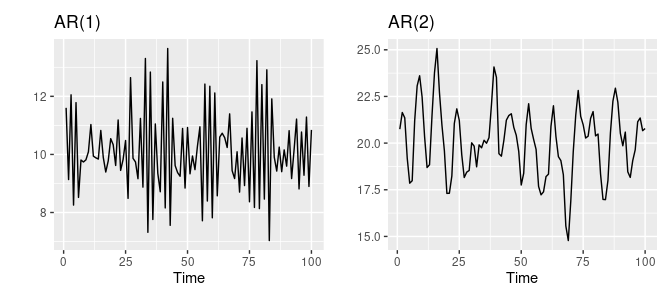

- In both cases $\varepsilon_t \sim N(0, 1)$. **Changing the variance of this term will only change the variance of the series, not the patterns**.
- Changing the $\phi_k$ parameters (within their constraints) generates different time series patterns.
- AR(1) in figure has equation $y_t = 18 - 0.8y_{t-1} + \varepsilon_t$
- AR(2) in figure has equation $y_t = 8 + 1.3y_{t-1} - 0.7y_{t-2} + \varepsilon_t$

# Moving Average models

Consider a white noise series $\varepsilon_t$ and think of $\varepsilon_t$ as a “shock” to the process at time $t$. A moving average model considers the forecast variable as a **regression on that shock and its past values**:

$$\begin{align*}
y_{t} = c + \varepsilon_t + \theta_{1}\varepsilon_{t-1} + \theta_{2}\varepsilon_{t-2} + \dots + \theta_{q}\varepsilon_{t-q},
\end{align*}$$

The name **moving average** is used because $y_t$ can be though as a weighted moving average of the past few “shocks”, although the coefficients of the regression rarely add up to one, as they would in a moving average. **Do not confuse moving average models with the moving average smoothing discussed in time series decomposition**.

A case of particular interest is to **consider the shocks** $\varepsilon_t$ as forecast errors. That is, to predict $y_t$ as a regression on previous forecast errors. Since independence does not hold in general for time series, this is a good way of modelling possible relationships between the errors of the latest few forecast values. Of course, **we do not observe the values of** $\varepsilon_t$, so it is not really a regression in the usual sense.

Unlike the autoregressive process, the **moving average process is stationary for any value of the parameters**. Below some examples of Moving Average processes:

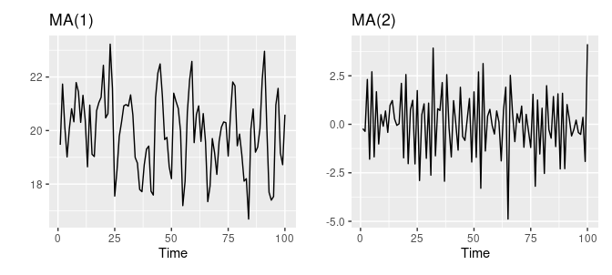

- In both cases $\varepsilon_t \sim N(0, 1)$. **Changing the variance of this term will only change the variance of the series, not the patterns**.
- Changing the $\theta_k$ parameters (within their constraints) generates different time series patterns.
- MA(1): $y_t = 20 + \varepsilon_t + 0.8\varepsilon_{t-1}$
- MA(2): $y_t = \varepsilon_t - \varepsilon_{t-1} + 0.8\varepsilon_{t-2}$

# Causality and autoregressive models - Autoregressive related to MA.

**Stationary** $AR(p)$ models can be written as an $MA(\infty)$ model. That is, we can find an expression for the $y_t$ of the $AR(p)$ model in terms of an infinite sum on $\varepsilon_t$ and its past values. We will show later that this is actually important in an ARIMA context.

As an example, an $AR(1)$ model could be written as an $MA(\infty)$ model as follows simply using recursive substitution:

$$\begin{align*}
y_t &= \phi_1y_{t-1} + \varepsilon_t\\
&= \phi_1(\phi_1y_{t-2} + \varepsilon_{t-1}) + \varepsilon_t\\
&= \phi_1^2y_{t-2} + \phi_1 \varepsilon_{t-1} + \varepsilon_t\\
&= \phi_1^3y_{t-3} + \phi_1^2\varepsilon_{t-2} + \phi_1 \varepsilon_{t-1} + \varepsilon_t\\
&\text{etc.}
\end{align*}$$

If the constraint $-1 < \phi_1 < 1$ is satisfied, the value $\phi_{1}^k$ decreases as $k$ increases. Hence extending the recursion to infinity the weight associated to the lag of $y_t$ in the recursion above would tend to 0 and we would reach the desired $MA(\infty)$ process:

$$\begin{align*}
y_t = \varepsilon_t + \phi_1 \varepsilon_{t-1} + \phi_1^2 \varepsilon_{t-2} + \phi_1^3 \varepsilon_{t-3} + \cdots = MA(\infty)
\end{align*}$$

Note that **the above was possible thanks to the constraint** $-1 < \phi_1 < 1$.

The term **“causality”** is used to signal that for such a model $y_t$ depends only on **the current shock** $\varepsilon_t$ and its past values

# Invertibility and Moving Average Models

If **certain constraints are imposed on the MA parameters** then we can ensure that the model is **invertible**, i.e. the $MA(q)$ process can be expressed as an $AR(\infty)$ process. In other words: we can obtain an expression for $\varepsilon_t$ as a regression of infinite terms of $y_t$ and its lags.

These invertibility constraints are similar to the stationary constraints for $AR(p)$ processes and are obtained by setting the coefficients $\theta, \theta_1,...\theta_q$ such that the complex roots of the following equation lie **outside the unit circle of the complex plane:**

$$1 - \theta_1z-\theta_2z^2-\dots-\theta_qz^q$$
The mathematical justification for this is complex and not in the scope of this course. The reader interested is referred to [2] and [3].

Here we give the conditions corresponding to the first values of $q$:

- For an $MA(1)$ model: $-1<\theta_1<1$
- For an $MA(2)$ model:
  - $-1<\theta_1<1$
  - $\theta_2+\theta_1 >-1$
  - $\theta_1 -\theta_2 < 1$
- For $q \geq 3$ the constraints get more complex, but they will be handled automatically by the `fable` package or other estimation software

## Some properties of invertible models

**Invertible models** have mathematical properties that make them desirable for forecasting uses.

As an example, let us consider the MA(1) model and try to give an interpretation of the significance of the invertibility conditions for this model. The MA(1) model has the form:

$$y_t = c + \varepsilon_t + \theta_1 \varepsilon_{t-1}$$
Re-arranging to obtain an expression for $\varepsilon_t$ and substituting recursively, we obtain:

$$\begin{align*}
\varepsilon_t &= y_t - c - \theta_1\varepsilon_{t-1} \\
&= y_t - c - \theta_1(y_{t-1} - c - \theta_1\varepsilon_{t-2}) \\
&= (y_t-\theta_1y_{t-1})-c(1+\theta_1)-\theta_1^2\varepsilon_{t-2} \\
&= \dots \\
&= (y_t-\theta_1y_{t-1}-\theta_1^2y_{t-2})-c(1+\theta_1+\theta_1^2)- \theta_1^3\varepsilon_{t-3} \\
&\text{etc.}
\end{align*}$$

The “$\dots$” in the equations above correspond to substituting $\varepsilon_{t-2}$ by $y_{t-2} - c - \theta_1\varepsilon_{t-3}$ expanding and grouping.

Extending the recursion to infinity we would reach the following expression for $\varepsilon_t$:

$$\begin{align*}
\varepsilon_t = \sum_{j=0}^\infty (-\theta_1)^j y_{t-j}-c\sum_{j=0}^\infty (-\theta_1)^j \tag{*}
\end{align*}$$

Now let us remember that the equation for the unit-roots of the model had led us to the following constraints for the values of _1 for an MA(1) model:

$$-1<\theta_1<1$$

Lets think about what these imply in equation $*$. We see indeed that the constraint $-1<\theta_1<1$ is the only one that makes sense. Let us examine the alternatives:

Therefore $|\theta_1|<1 \rightarrow -1<\theta_1<1$ is the only contraint that makes sense for an MA(1) model from a forecasting perspective.

# ARMA(p, q) models

Combining $AR(p)$ and $MA(q)$ processes we can produce $ARMA(p,q)$ processes. These are very flexible for handling **stationary time series**.

$$\begin{equation}
y_{t} = c + \phi_{1}y_{t-1} + \cdots + \phi_{p}y_{t-p}
+ \theta_{1}\varepsilon_{t-1} + \cdots + \theta_{q}\varepsilon_{t-q} + \varepsilon_{t}
\end{equation}$$

When we start combining models in this manner, it is useful to use the backshift notation:

$$\begin{equation}
\tag{9.2}
\begin{array}{c c c c}
(1-\phi_1B - \cdots - \phi_p B^p)y_t = &c + (1 + \theta_1 B + \cdots + \theta_q B^q)\varepsilon_t\\
{\uparrow} & {\uparrow}\\
\text{AR($p$)} & \text{MA($q$)}\\
\end{array}
\end{equation}$$

### ARMA Models and stationary processes:

These statements are proved in references [2] and [3].

- Mathematically, Wold’s decomposition theorem shows that any stationary time series may be represented as a linear combination of white noise.
- On the other hand, the stationarity and invertibility properties we have discussed show that any ARMA model can be expressed in a form that is, in the end, a linear combination of white noise (provided the stationarity and invertibility constraints on the parameters are satisfied).
  - The $AR(p)$ part of the model can be expresed as an $MA(\infty)$ (which is a linear combination of white noise)
  - The $MA(q)$ part of the model is already a linear combination of white noise.

This means that ARMA models, because they can be expressed as a linear combination of white noise, are capable of modelling **stationary time series**. It **may not always be the best model, but models of this form are viable for stationary time series and therefore are very wide-spread through the industry**.

### Order selection for ARMA(p,q) processes:

Selecting appropriate values for $p$ and $q$ can be difficult. We will use two approaches:

1. Inspecting the **Autocorrelation (ACF) and Partial Autocorrelation (PACF)** diagrams **of the stationary process**. This will let us infer appropriate values for $p$ and $q$ and later try a few more models around these values
2. Using the automatic search in the `ARIMA()` function from the `fable()` package, which looks for values of $p$ and $q$ that minimize information criteria (by default AICc). However this approach has its own caveats, as we will explore in the examples.

It is important to have both approaches clear, because simply using `ARIMA()` and letting it choose the model for you can in many instances lead to over-parametrized models that may be easily avoidable.

#### ACF

Measures the relationship between $y_t$ and its lags $y_{t-k}$. Part of the relationship between the variable and its k-th lag may be due to the lags in between:

- If $y_t$ and $y_{t-1}$ are correlated, $y_{t-1}$ and $y_{t-2}$ are also correlated
- Therefore $y_t$ and $y_{t-2}$ might be correlated simply because they are both connected to $y_{t-1}$ rather than due to information contained in $y_{t-2}$ that could be useful to forecast $y_t$.

#### PACF - Partial Autocorrelation Function

Many times we want to find the correlation between two variables, but removing the effect of other variables. This is known as partial autocorrelation.

In the case of a time series ${y_t}$, it corresponds to finding the linear relationship between variables $(y_t, y_{t-k})$ while removing the effect of all the lags in-between them: $y_{t-1}, y_{t-2},\dots , y_{t-k+1}$.

In more general but simplified terms, if we had three variables $x$, $y$ and $z$, the partial autocorrelation between $x$ and $y$ removing the effect of z would be the correlation between $x$ and $y$ having removed any effect derived from the fact that both $x$ and $y$ might be correlated to $z$. We write this function as:

$$\rho_{xy|z}=corr\{x-\hat x, y-\hat y\}$$
There is an **easy interpretation of partial autocorrelation in terms of the coefficients of a linear regression model**. Think of the following two models:

$$y_t = \beta_0 + \beta_1x$$

$$y_t = \beta_0+\beta_1x+\beta_2z$$

In the case of time series, we could fit an **autoregression model** (a regression of the series $y_t$ on its lagged values) and perform a similar interpretation. Consider the following two models:

$$y_t = \beta_0 + \phi_1y_{t-3}$$

$$y_t = \beta_0+\phi_1y_{t-1}+\phi_2y_{t-2}+\phi_3y_{t-3}$$

In the first model, $\phi_1$ can be interpreted as the linear dependency between $y$ and $y_{t-3}$. In the second model, $\phi_3$ would be interpreted as the linear dependency between $y$ and $y_{t-3}$ with the linear dependency between $y$ and $y_{t-1}$ and $y_{t-2}$ already accounted for.

Following this line of reasoning, it is clear that **the first autocorrelation coefficient is equal to the first partial autocorrelation coefficient**, because there are no lags in between $y_t$ and $y_{t-1}$.

This was a short introduction to the concept of partial autocorrelation, which we will be using in the coming sections.

#### ACF and PACF of AR(p), MA(q) and ARMA(p, q) models

This section summarizes the way to assess the ACF and PACF plots to manually select values for the orders $p$ and $q$ of the model.

To fully understand it, the examples that follow this section are essential.

**Once the data has been made stationary, we know that we can model the resulting time process using an ARMA process** (see section on the Wold Decomposition). At this point **we want to compute the ACF and PACF diagram** because **they may assist us in determining the orders p and q of the model**

**The plots must be generated for the stationary data**, since it is **this data that can be modeled using an ARMA process**.

When inspecting the plots, the following table (ref 2. and 3.) can be used to determine the orders:

|  | AR(p) (q=0) | MA(q) (p=0) | ARMA(p,q) |
| --- | --- | --- | --- |
| ACF | Tails-off | Cuts off after lag q | Tails-off |
| PACF | Cuts-off after lag p | Tails off | Tails-off |

In this table:

- `tails-off` means that the function is exponentially decaying, sinusoidal or sinusoidally decaying.
- `cuts-off` means that there are no relevant autocorrelation coefficients beyond lag p (if we are dealing with the AR case) or q (if we are dealing with the MA case).

There are a couple of special cases:

- **Case where both cut-off**: it can be shown that for an ARMA process this is theoretically not possible. However **for real data there are situations where the graphs are so that this might seem the case**. In this situation we will **fit two models**:
1. MA(q) model suggested by the cut-off of the ACF at lag q.
2. AR(p) model suggested by the cut-off of the PACF at lag p.
- **Case where both tail-off**: in the case where both p and q are positive (ARMA model), then the ACF and PACF will both tail-off and the diagrams are not very helpful in identifying the order of either $p$ or $q$. **In this case we will resort to an automatic search based on AIC.**
  - NOTE: a manual search in this case is possible but we will not follow this approach based on starting with p=1 and q=1 (looking for parsimonious models) and doing a manual search. To learn more about this approach and manual fitting in general, there is a good course on line on fitting ARIMA models by the authors of references 2 and 3: [Link](https://www.datacamp.com/courses/arima-models-in-r).

**All this is better understood through the examples in the following section**.

**Important note**: keep in mind that in ARIMA models, the information criteria can be compared only among models with the same order of differencing. This will be later explained, but it is important that you keep this in mind. The reason is that differencing changes the data to which the ARMA model is fitted (it removed the trend and the seasonality!).

#### Examples of ACF and PACF functions of simulated data:

I am going going to use the function `sarima.sim` from an additional library, `astsa` (associated to references [2] and [3]). This function enables us to quickly simulate AR and MA processes. That is: we are going to define a data generating process and use it to create a sample of artificial data (just like when we extract 100 samples from a normal distribution to create white noise).

We are then going depict the ACFs and PACFs of these samples and see if the patterns match what we would expect in order to recognize the values of $p$ and $q$ if we were to manually fit the model.

Finally we are going to see if the automated function `ARIMA()`, from the package `fable`, is capable of detecting the underlying data generating process from the data.

##### AR(1) simulation example

Let us simulate a model $AR(1)$ with parameter $\phi=0.75$:

```
Plot variable not specified, automatically selected `.vars = value`
```

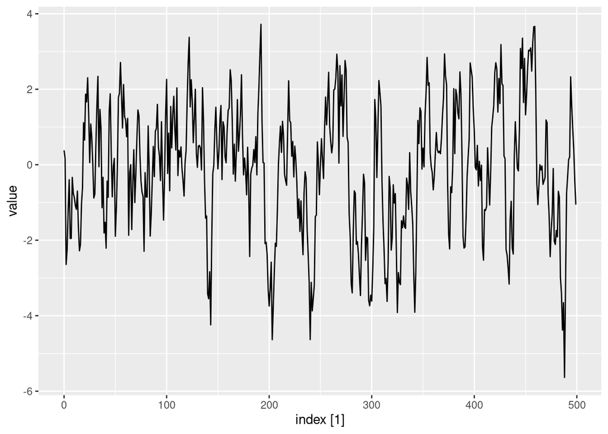

```r
set.seed(1011)
y_ar1 <- sarima.sim(ar=c(0.75)) %>% as_tsibble()
y_ar1 %>% autoplot()
```

Now we can depict the ACF and PACF. Either separately or using `gg_tsdisplay()`:

```
Response variable not specified, automatically selected `var = value`
```

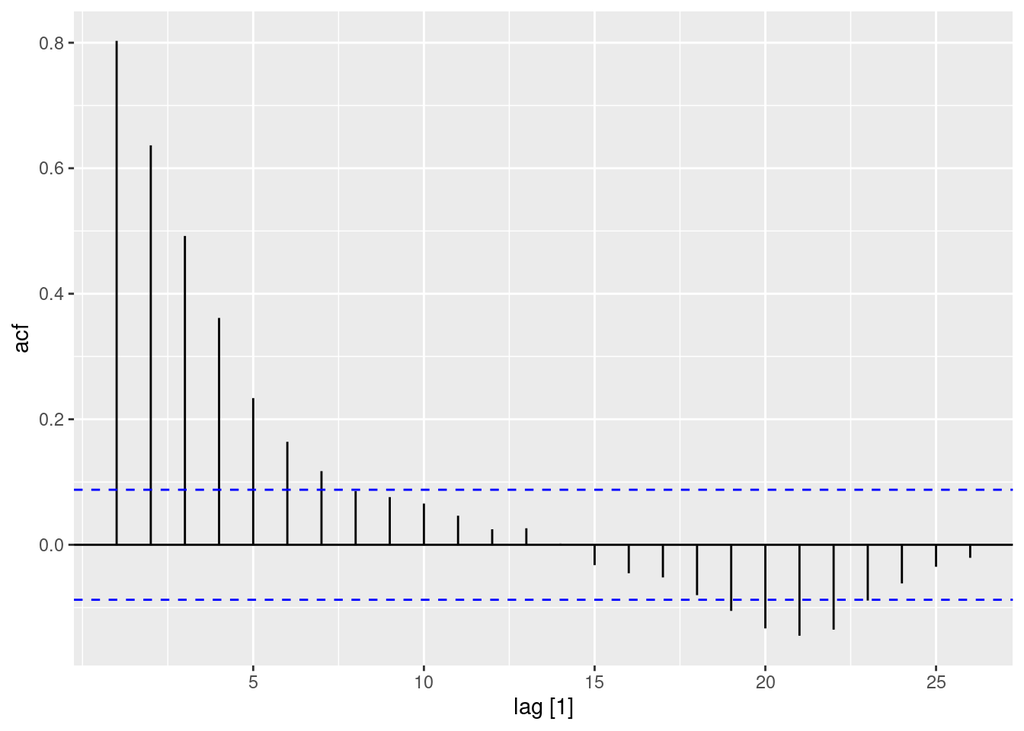

```r
y_ar1 %>% ACF() %>% autoplot()
```

```
Response variable not specified, automatically selected `var = value`
```

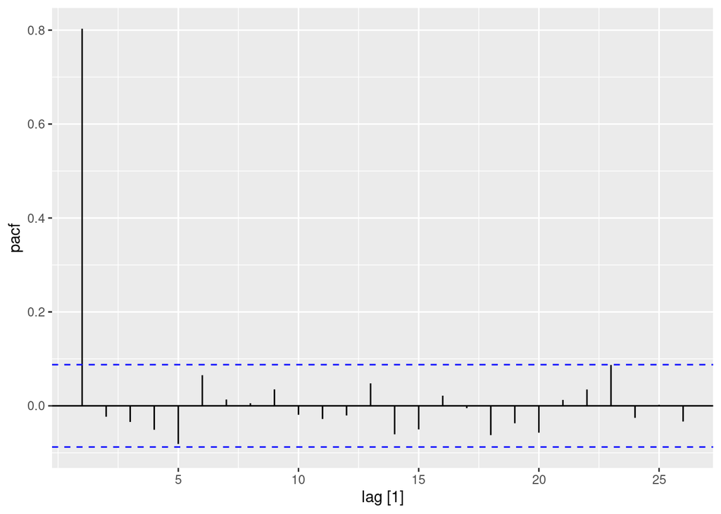

```r
y_ar1 %>% PACF() %>% autoplot()
```

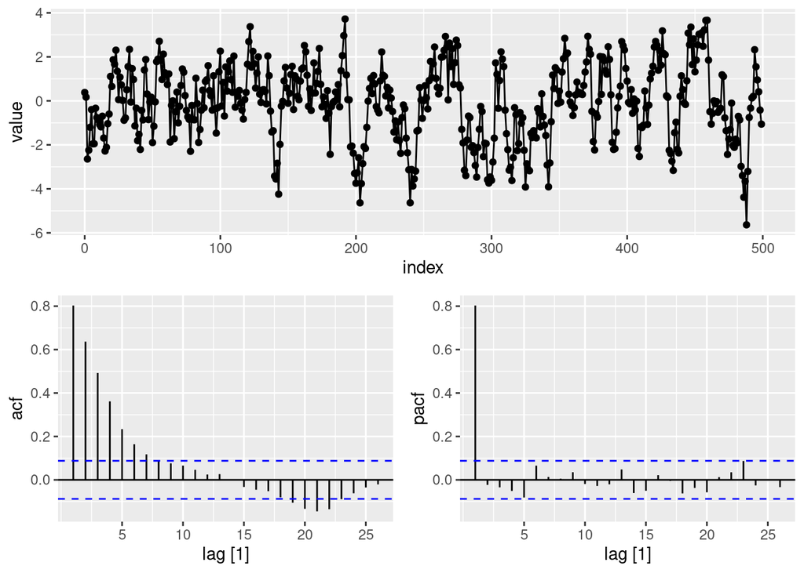

```r
y_ar1 %>% gg_tsdisplay(value, plot_type="partial")
```

In this case the pattern is very recognizable due to:

1. The fact that this is a pure AR() model that we have simulated and not real data
2. The values of the parameters.

Real data may be a bit more difficult to spot due to its inherent noise. We will see some examples of this.

Let us see if the ARIMA function is capable of detecting the actual data generating process:

```r
fit_ar1_auto <- y_ar1 %>% model(ARIMA())
```

```
Model not specified, defaulting to automatic modelling of the `value` variable.
Override this using the model formula.
```

```r
fit_ar1_auto %>% report()
```

```
Series: value
Model: ARIMA(1,0,0)

Coefficients:
         ar1
      0.8028
s.e.  0.0265

sigma^2 estimated as 1.062:  log likelihood=-724.6
AIC=1453.19   AICc=1453.21   BIC=1461.62
```

In this case, the function `ARIMA()` successfully detects the true data generating process.

Now let us check if the model fulfils the conditions of the residuals (normality of the residuals is critical in the case of ARIMA models to have accurate prediction intervals):

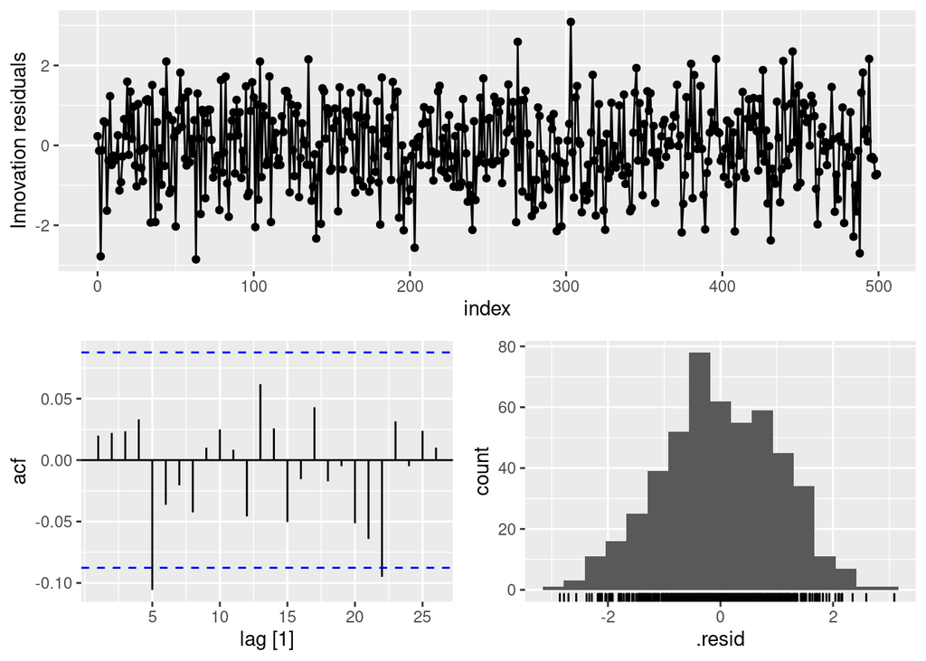

```r
fit_ar1_auto %>% gg_tsresiduals()
```

The residuals appear to be normal. There seems to be a bit of autocorrelation. But we know for a fact that this is the true data generating process! This is probably because we have a limited sample and thus the false positives. It goes to show that even the true data generating process (which does not need improvement) can exhibit some autocorrelation on the residuals due to the limited sample.

##### AR(2) simulation example

Let us simulate a model $AR(2)$ with parameter $\phi_1=0.75$ and $\phi_2 = -0.8$:

```
Plot variable not specified, automatically selected `.vars = value`
```

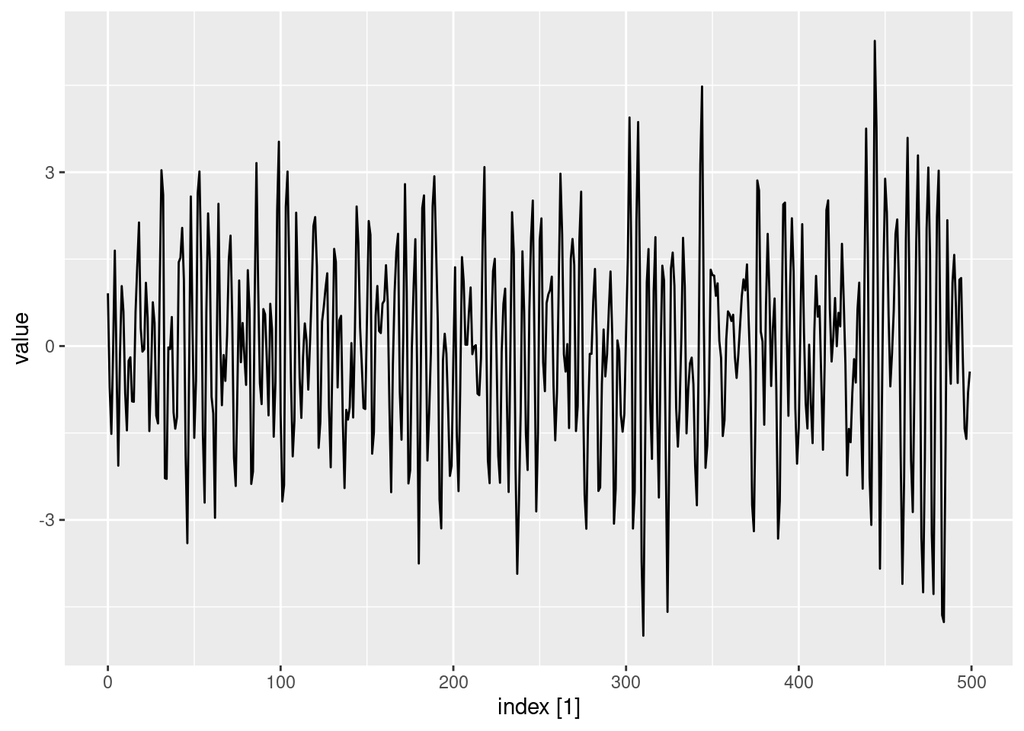

```r
set.seed(1011)
y_ar2 <- sarima.sim(ar=c(0.75, -0.8)) %>% as_tsibble()
y_ar2 %>% autoplot()
```

```
Response variable not specified, automatically selected `var = value`
```

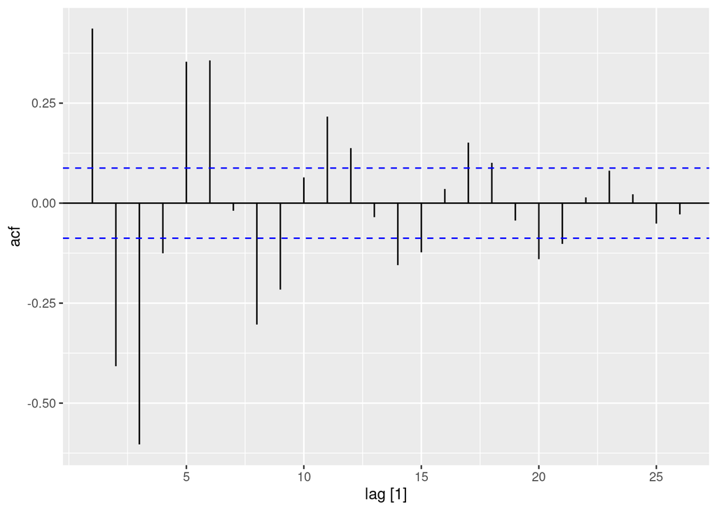

```r
y_ar2 %>% ACF() %>% autoplot()
```

```
Response variable not specified, automatically selected `var = value`
```

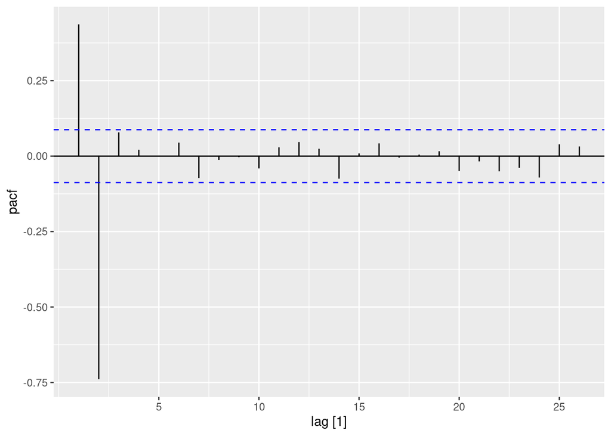

```r
y_ar2 %>% PACF() %>% autoplot()
```

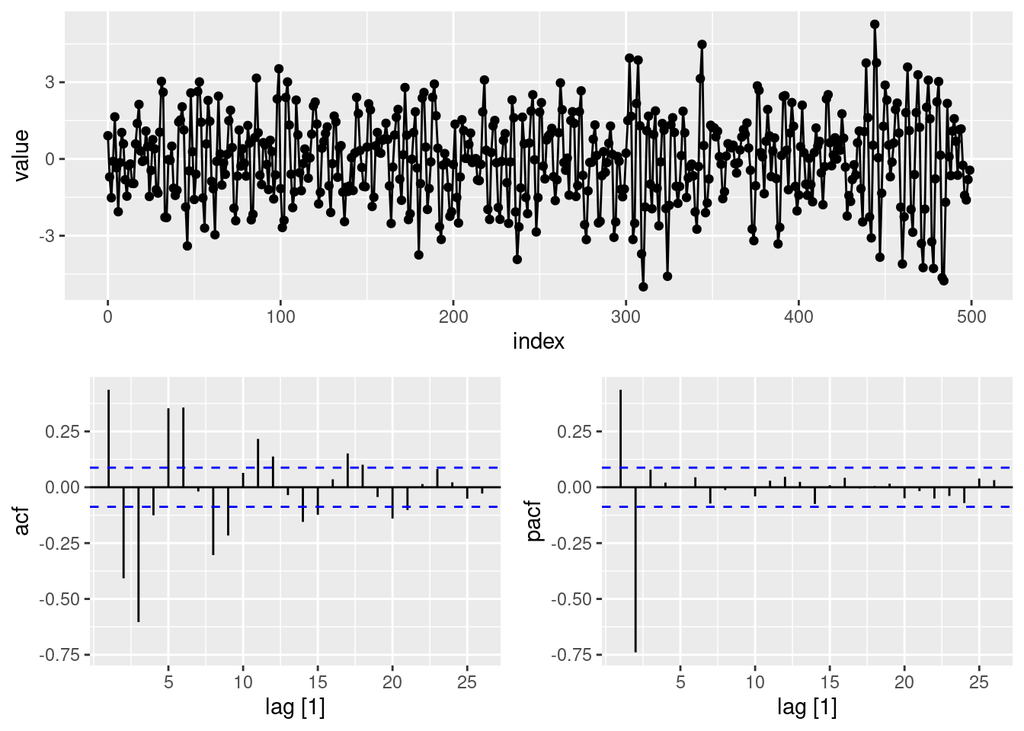

```r
y_ar2 %>% gg_tsdisplay(value, plot_type="partial")
```

This time PACF cuts-off at lag 2, as expected from an AR2 model. ACF tails off, but its does so in a different manner (still sinusoidal though) than before.

Let us see if the `ARIMA()` function now recognizes the underlying model:

```r
fit_ar2_auto <- y_ar2 %>% model(ARIMA())
```

```
Model not specified, defaulting to automatic modelling of the `value` variable.
Override this using the model formula.
```

```r
fit_ar2_auto %>% report()
```

```
Series: value
Model: ARIMA(2,0,1)

Coefficients:
         ar1      ar2     ma1
      0.7143  -0.7184  0.1002
s.e.  0.0409   0.0336  0.0576

sigma^2 estimated as 1.045:  log likelihood=-719.99
AIC=1447.98   AICc=1448.06   BIC=1464.84
```

This means that **the automated approach fails to recognise the true data generating process**. **However, in a real scenario, where we do not actually know the true data generating process, this model might be good enough**. We will judge its fit with information criteria and residuals analysis and its performance as usual using, for example, cross-validation.

Let us check the residuals:

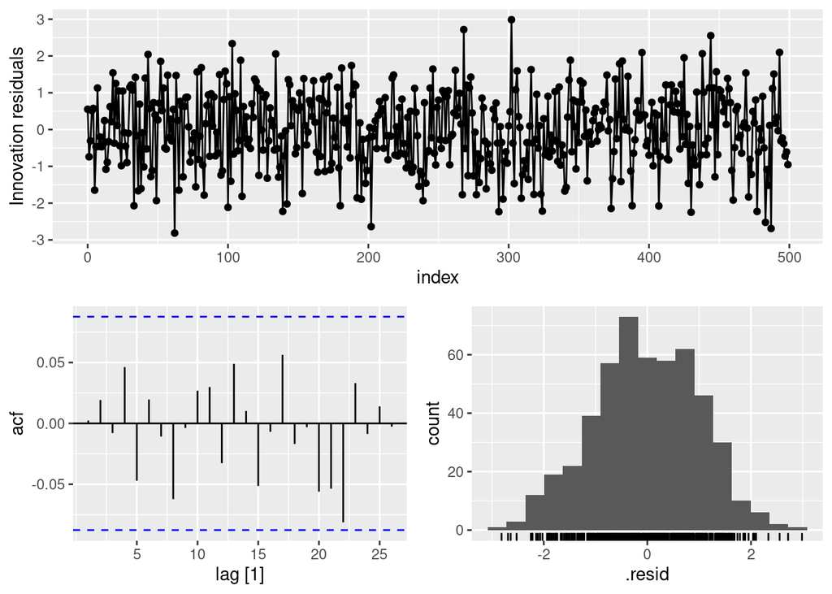

```r
fit_ar2_auto %>% gg_tsresiduals()
```

The model seems good in terms of normality, autocorrelation of the residuals and homoskedasticity, **even though it is not the true data generating process**. In a real scenario, where we did not know the true data generating process, this model would be sensible for forecasting.

###### Remark: AIC vs BIC discussion

Let us compare the AIC of this automatically fitted model with the performance of a model fitted using the correct value of the orders (p=2, q=0):

```r
y_ar2 %>% model(
            manual = ARIMA(value ~ pdq(2,0,0)),
            auto_arima = ARIMA(),
            auto_arima_bic = ARIMA(ic="bic")
          ) %>% glance()
```

```
Model not specified, defaulting to automatic modelling of the `value` variable. Override this using the model formula.
Model not specified, defaulting to automatic modelling of the `value` variable. Override this using the model formula.
```

```
# A tibble: 3 × 8
  .model         sigma2 log_lik   AIC  AICc   BIC ar_roots  ma_roots
  <chr>           <dbl>   <dbl> <dbl> <dbl> <dbl> <list>    <list>
1 manual           1.05   -721. 1449. 1449. 1462. <cpl [2]> <cpl [0]>
2 auto_arima       1.05   -720. 1448. 1448. 1465. <cpl [2]> <cpl [1]>
3 auto_arima_bic   1.05   -721. 1449. 1449. 1462. <cpl [2]> <cpl [0]>
```

- Note that **the auto_arima model is best than the manual model in terms of AICc and AIC!** Remember however that **AICc is not focused on looking for the true data generating process** and this better performance is due to the limited sample we have.
- However note that the BIC of the model following the true data generating process (the manually fitted model) is better (smaller). This is because **given enough data, BIC has a feature that, if there is a true underlyting model, it will select it**. In this case it was able to pick on it.
- Also note that the `auto_arima_bic` model managed to capture the true underlyting process thanks to the mentioned feature of BIC.

Then… **why not always use BIC?** Because:

1. There is **rarely if ever a true underlying model**. And even if there is, we cannot be sure we have captured it, regardless of whether we use BIC as the criteria for model selection (the sample might not be big enough).
2. **Even if there is a corresponding true underlying model, it will not necessarily give the best forecasts**. This is because **the parameter estimates may not be accurate** (remember we need to estimate the values of all the model parameters from the data).

##### Alternative AR(2) simulation example

Note that **if we change the parameters of our simulation the behavior of the model might cease to be so clearly recognizable**

```
Plot variable not specified, automatically selected `.vars = value`
```

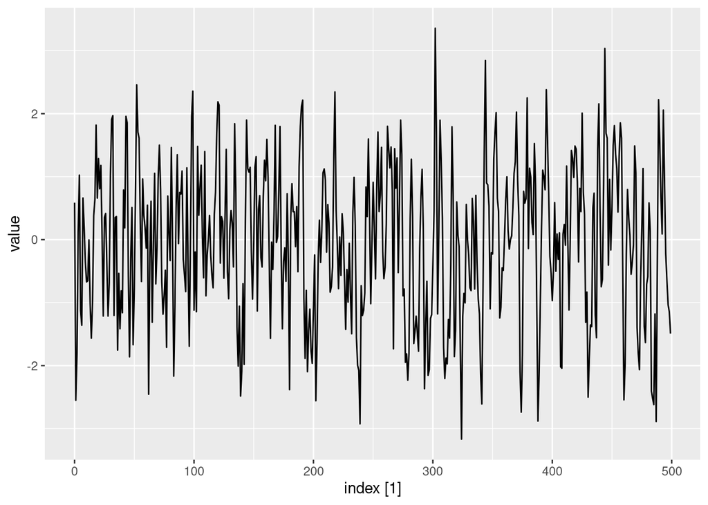

```r
set.seed(1011)
y_ar2_alt <- sarima.sim(ar=c(0.55, -0.25)) %>% as_tsibble()
y_ar2_alt %>% autoplot()
```

```
Response variable not specified, automatically selected `var = value`
```

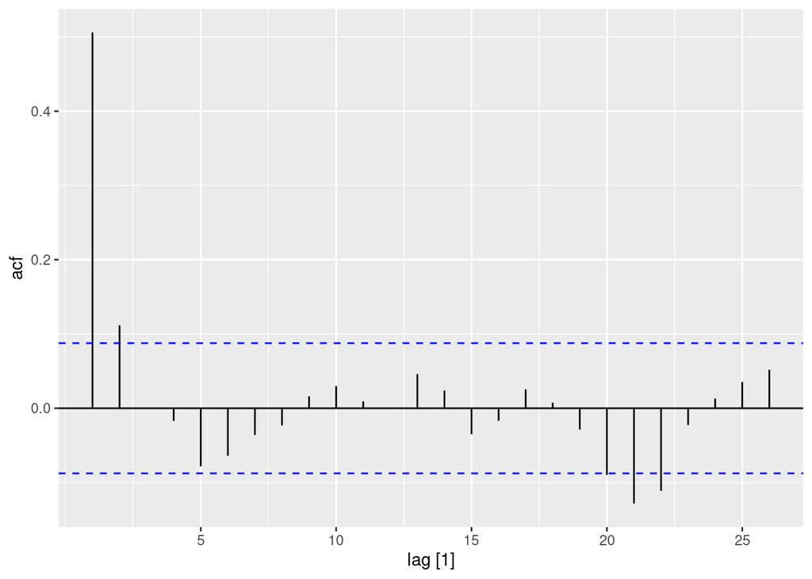

```r
y_ar2_alt %>% ACF() %>% autoplot()
```

```
Response variable not specified, automatically selected `var = value`
```

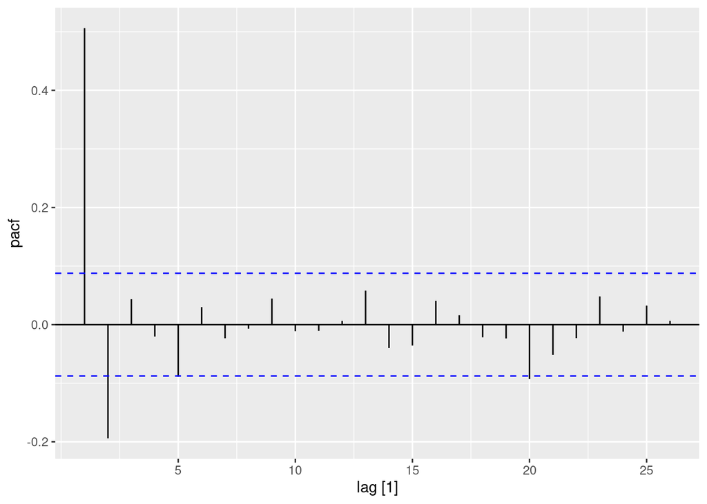

```r
y_ar2_alt %>% PACF() %>% autoplot()
```

Alternatively:

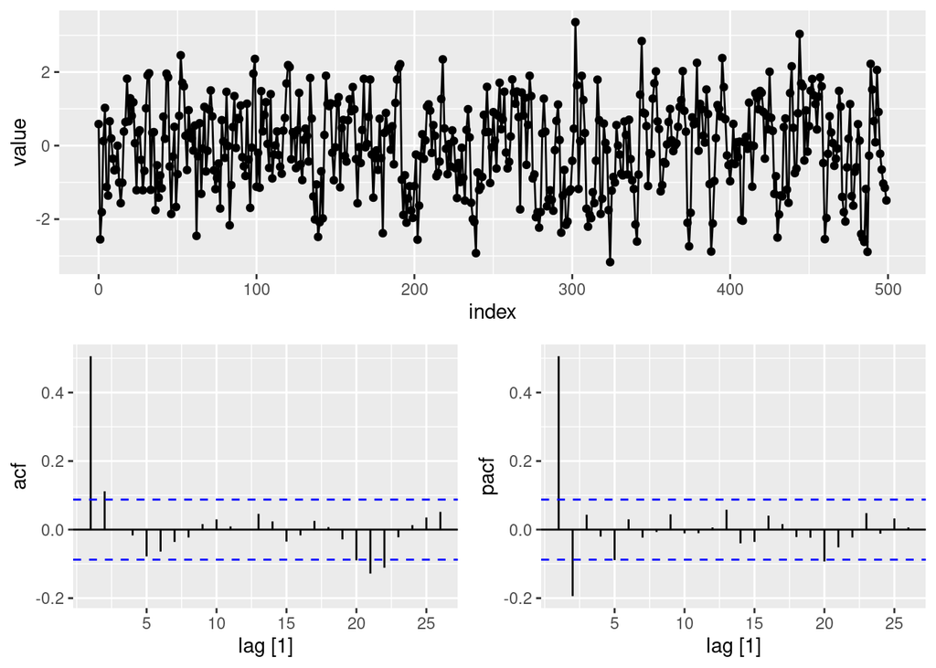

```r
y_ar2_alt %>% gg_tsdisplay(value, plot_type="partial")
```

In this case:

- The ACF is still tailing off, only it is less obvious and it might be confused with cutting off rather than tailing off!.
- The PACF is cutting off at lag 2, indicating p=2.

Let us check how the automated ARIMA() model does:

```r
y_ar2_alt %>% model(ARIMA()) %>% report()
```

```
Model not specified, defaulting to automatic modelling of the `value` variable.
Override this using the model formula.
```

```
Series: value
Model: ARIMA(2,0,0)

Coefficients:
         ar1      ar2
      0.6081  -0.1979
s.e.  0.0440   0.0442

sigma^2 estimated as 1.062:  log likelihood=-723.68
AIC=1453.36   AICc=1453.41   BIC=1466.01
```

##### MA(2) model

```
Plot variable not specified, automatically selected `.vars = value`
```

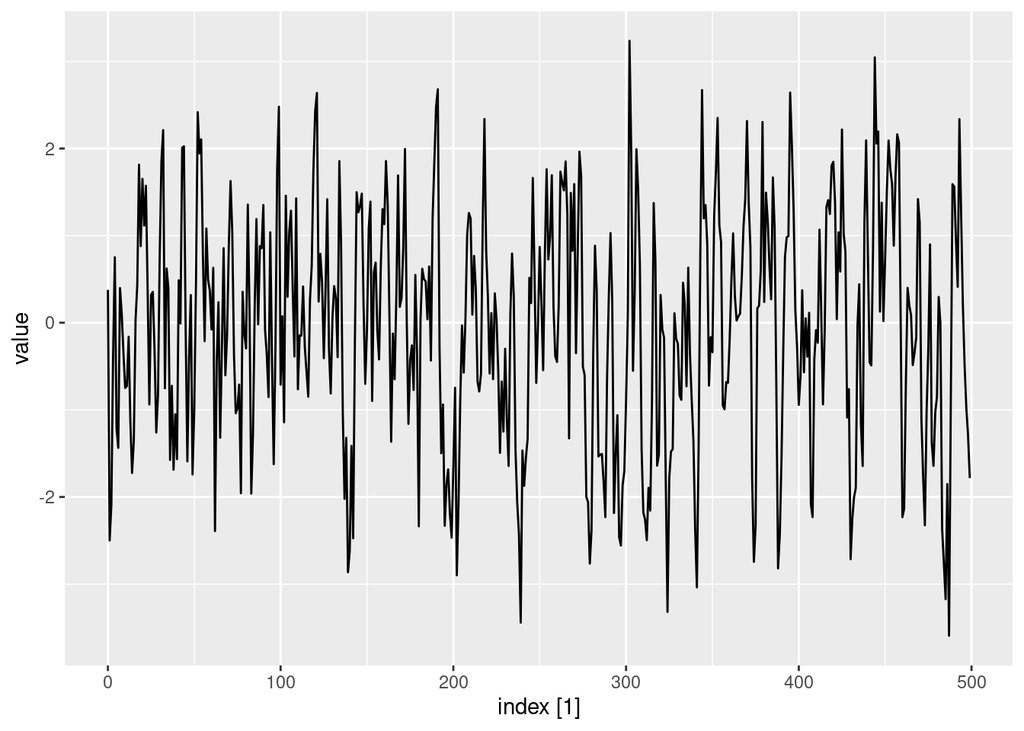

```r
set.seed(1011)
y_ma2 <- sarima.sim(ma=c(0.65, 0.25)) %>% as_tsibble()
y_ma2 %>% autoplot()
```

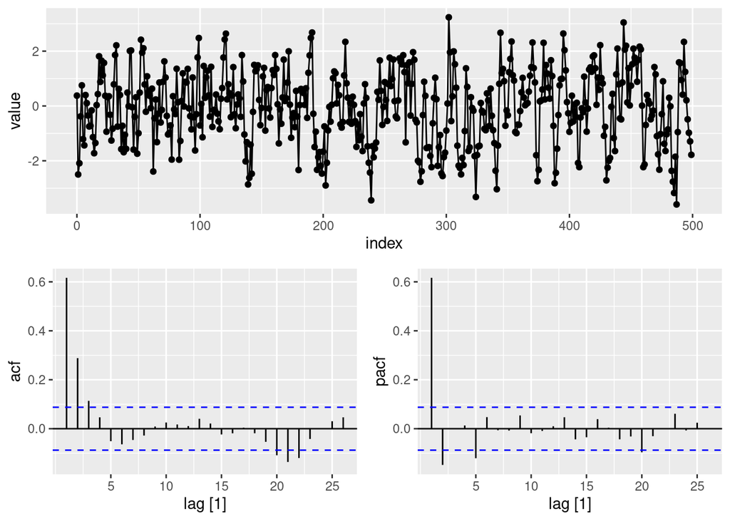

```r
y_ma2 %>% gg_tsdisplay(value, plot_type="partial")
```

This being an MA(2) (and we know for a fact it is because we simulated it), we would expect (check the table) a cut-off in the ACF after lag 2 and a tail-off of the PACF.

However the behavior is not clearly recognizable in the graphs above and so if we only had the data but and did not know the underlying true proces we would not identify the correct orders.

In this situation we would probably mistakenly fit a PACF model with p=2 or p=5 (see cut-off of the PACF). This means we would have failed to manually identify the true data generating process.

Lets try this “mistakenly” identified model alung with the true model and an automatically fitted model:

```r
fit_ma2 <- y_ma2 %>% model(
              manual_1 = ARIMA(value ~ pdq(2,0,0)),
              true = ARIMA(value ~ pdq(0,0,2)),
              auto = ARIMA(value, stepwise = FALSE)
            )

fit_ma2 %>% glance()
```

```
# A tibble: 3 × 8
  .model   sigma2 log_lik   AIC  AICc   BIC ar_roots  ma_roots
  <chr>     <dbl>   <dbl> <dbl> <dbl> <dbl> <list>    <list>
1 manual_1   1.07   -725. 1456. 1456. 1469. <cpl [2]> <cpl [0]>
2 true       1.07   -725. 1457. 1457. 1469. <cpl [0]> <cpl [2]>
3 auto       1.06   -721. 1456. 1456. 1485. <cpl [2]> <cpl [4]>
```

```r
fit_ma2 %>% select(auto) %>% report()
```

```
Series: value
Model: ARIMA(2,0,4)

Coefficients:
         ar1      ar2     ma1     ma2     ma3     ma4
      0.2972  -0.2424  0.4250  0.3919  0.1963  0.1924
s.e.  0.4970   0.3980  0.4918  0.2306  0.1730  0.1003

sigma^2 estimated as 1.058:  log likelihood=-720.91
AIC=1455.81   AICc=1456.04   BIC=1485.31
```

See that the model has an AIC similar to the true model and satisfies the conditions on the residuals:

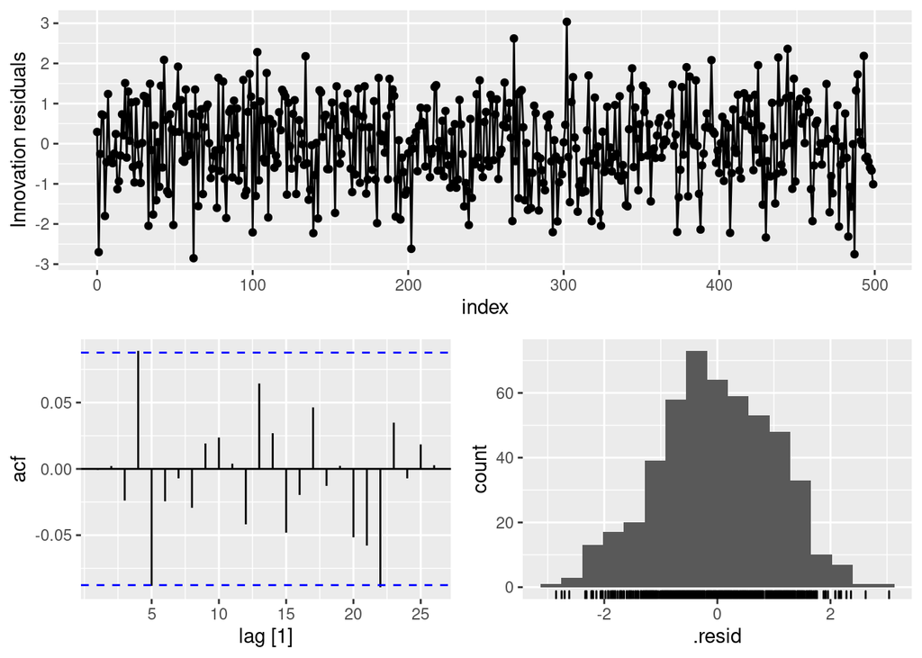

```r
fit_ma2 %>% select(manual_1) %>% gg_tsresiduals()
```

Cross-validation ot train-test testing would be a way to assess the forecasting accuracy of this model, despite it not representing the true underlying model.

##### Extreme case: overparametrized white-noise

This case is here only to prove the potential risks associated to automatic forecasting techniques. The code below generates a sample of white noise and fits and automated ARIMA model to it:

```r
set.seed(666)
y_norm <- rnorm(1000) %>% as_tibble() %>% mutate(index=row_number()) %>% as_tsibble(index=index)

fit_wnoise <- y_norm %>% model(ARIMA())
```

```
Model not specified, defaulting to automatic modelling of the `value` variable.
Override this using the model formula.
```

```r
fit_wnoise %>% report()
```

```
Series: value
Model: ARIMA(2,0,1)

Coefficients:
          ar1      ar2     ma1
      -0.9744  -0.0477  0.9509
s.e.   0.0429   0.0321  0.0294

sigma^2 estimated as 0.9657:  log likelihood=-1400
AIC=2808.01   AICc=2808.05   BIC=2827.64
```

The automatic method has not been able to properly identify this particular sample of white noise and has fitted an ARIMA(2, 0 , 1) model! (ARMA(2,1)).

However simply by checking the ACF and PACF we could have seen that this is indeed white noise:

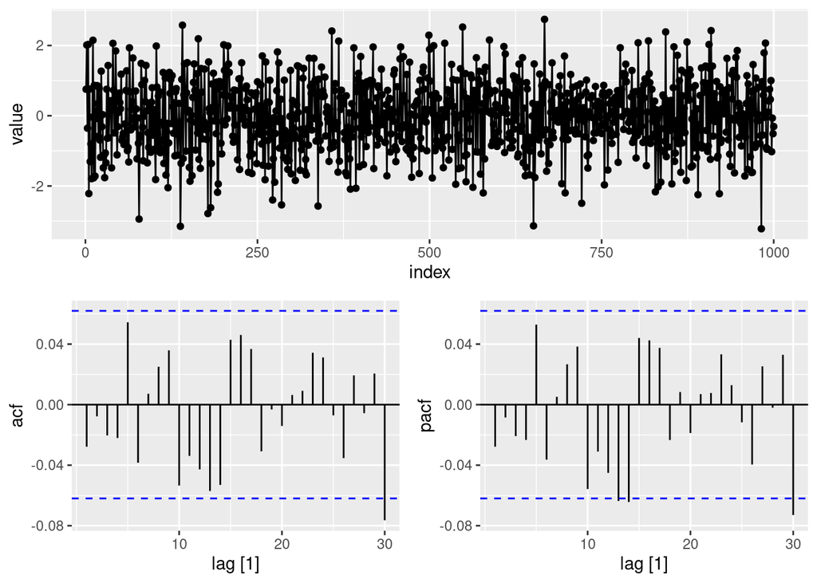

```r
y_norm %>% gg_tsdisplay(value, plot_type="partial")
```

Here we can see how it is very good practice to at least check the ACF and PACF prior to blindly fitting `ARIMA()` to our data. Again auto-ARIMA has failed to recognize the true underlying model. This is the reason it is an equally beloved and criticized approach.

**Takeaway:** unless you are in a scneario where you really need automatic forecasting to process a lot of time series, it is always a good idea to check the ACF and PACF. The underlying model might be blatantly obvious. Do not be lazy.

#### Example Egyptian Exports

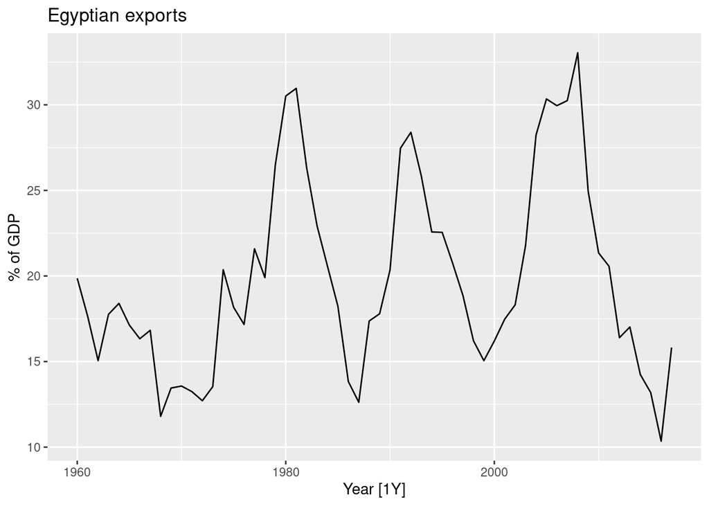

```r
eg_exports <- global_economy %>%
  filter(Code == "EGY")

eg_exports  %>%
  autoplot(Exports) +
  labs(y = "% of GDP", title = "Egyptian exports")
```

Looking at the data above we can see that is stationary. It does not have a clear trend or seasonality, but rather cyclicity (and remember cicles are not a cause of not-stationarity). It also does not exhibit changes in variance. Let us check this with our unit-root kpss test:

```r
eg_exports %>%
  features(Exports, unitroot_kpss)
```

```
# A tibble: 1 × 3
  Country          kpss_stat kpss_pvalue
  <fct>                <dbl>       <dbl>
1 Egypt, Arab Rep.     0.192         0.1
```

The p-value is large enough so that the null cannot be rejected. That is, the data is stationary. Therefore this time series can be modelled by an ARMA process. Let us check the ACF and PACF:

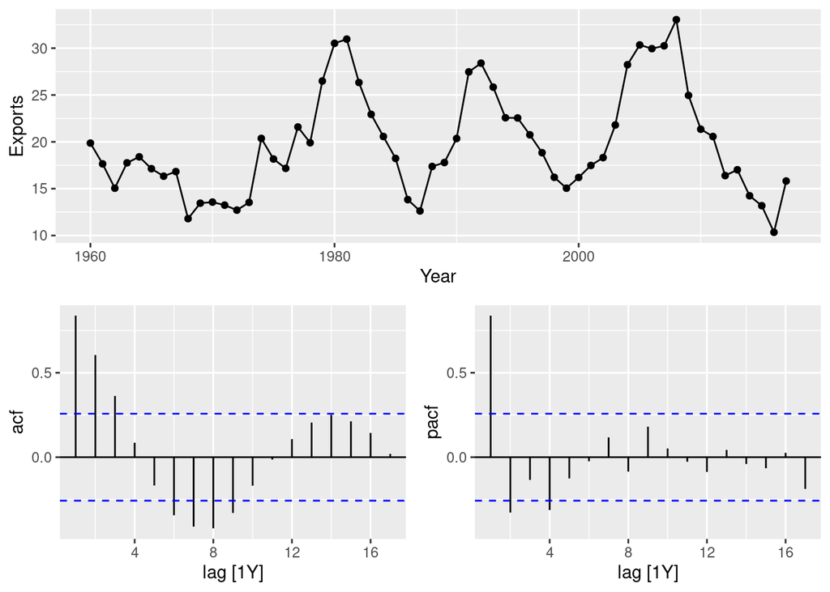

```r
eg_exports %>% gg_tsdisplay(Exports, plot_type="partial")
```

The ACF tails-off and the PACF seems to have a cut-off at lag 4. This corresponds to an AR(4) = ARMA(4,0) = ARIMA(4, 0, 0). Let us feet this model along with a model in which we will specify some constrains for the parameters:

```r
fit_eg <- eg_exports %>%
  model(
        auto_arima = ARIMA(Exports),
        man_ar4 = ARIMA(Exports ~ pdq(4,0,0)),

        # Specify search constraints
        rest_arima = ARIMA(Exports ~ pdq(p=1:3, d=0, q=0:1))
        )

glance(fit_eg)
```

```
# A tibble: 3 × 9
  Country          .model     sigma2 log_lik   AIC  AICc   BIC ar_roots  ma_ro…¹
  <fct>            <chr>       <dbl>   <dbl> <dbl> <dbl> <dbl> <list>    <list>
1 Egypt, Arab Rep. auto_arima   8.05   -142.  293.  294.  303. <cpl [2]> <cpl>
2 Egypt, Arab Rep. man_ar4      7.88   -141.  293.  295.  305. <cpl [4]> <cpl>
3 Egypt, Arab Rep. rest_arima   8.05   -142.  293.  294.  303. <cpl [2]> <cpl>
# … with abbreviated variable name ¹ma_roots
```

```r
# NOTE THE DIFFERENCE IN AIC and AICc when picking up the model!
```

We can see that the model we have manually fitted is only slightly worse in terms of AICc than the automatically fitted model (note that for AIC it is even better. This is related to the small sample correction of AICc).

```r
fit_eg %>% select(auto_arima) %>% report()
```

```
Series: Exports
Model: ARIMA(2,0,1) w/ mean

Coefficients:
         ar1      ar2      ma1  constant
      1.6764  -0.8034  -0.6896    2.5623
s.e.  0.1111   0.0928   0.1492    0.1161

sigma^2 estimated as 8.046:  log likelihood=-141.57
AIC=293.13   AICc=294.29   BIC=303.43
```

Auto-arima has a model with one less parameter. It is an ARIMA(2, 0, 1).

Finally note that the residuals of the model seem to fulfil all relevant conditions. To assess its forecasting performance we would use test-train or cross-validation.

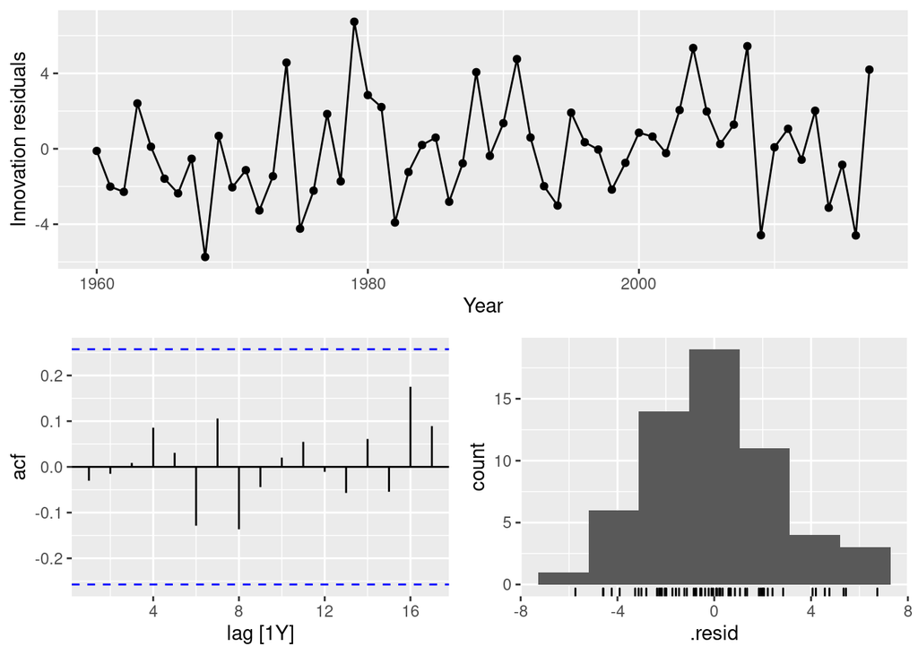

```r
fit_eg %>%
  select(man_ar4) %>%
  gg_tsresiduals()
```

```r
# Large value of p, suggesting the residuals are white noise
augment(fit_eg) %>%
  filter(.model=='man_ar4') %>%
  features(.innov, ljung_box, lag = 10, dof = 3)
```

```
# A tibble: 1 × 4
  Country          .model  lb_stat lb_pvalue
  <fct>            <chr>     <dbl>     <dbl>
1 Egypt, Arab Rep. man_ar4    3.95     0.786
```

Ljung-Box statistical test also yields non-significant results, so we can conclude that the residuals are not distinguishable from white noise.

##### Roots of the ARMA process:

Finally let us **depict the roots (the zeros) of the characteristic polynomials of the AR and MA part of the ARMA process**. Remember that to satisfy the constraints of the coefficients of the models we needed these to be **outside the unit circle of the complex plane**. The graph below performs and inverse transformation and shows the roots **within the circle** because **this makes the results easier to check**.

Comments on the interpretation:

- The ARIMA() function **does not fit models that do not fulfill the unit root conditions**.
- We want points to be separated from the unit circle as possible. Roots close to the unit circle might result in numerical instabilities!.
  - **This could be a criteria to select between two candidate ARIMA models if they are similar in all other metrics** (parsimony, residuals, information criteria, cross-validated accuracy)…

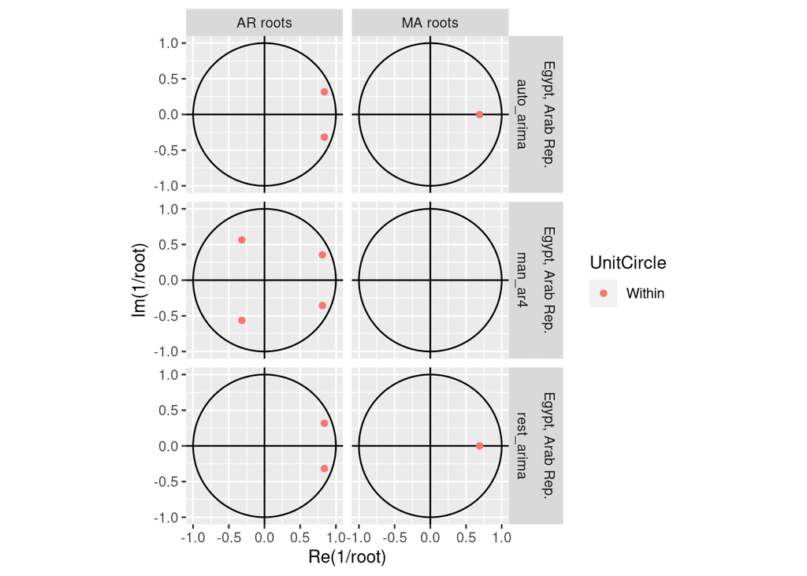

```r
fit_eg %>% gg_arma()
```

In this case all of the models fitted have two AR roots quite close to the unit circle, so no model is particularly better than another.

# Summary of ideas

## Theory part

### **Auroregression models** $AR(p)$

- **linear combination of past values of the variable** $y_{t-k}$.
- Restrictions on the coefficients apply to guarantee $AR(p)$ models stationary data.
  - Restrictions obtained forcing values of the coefficients such that the roots (zeros) of the characteristic polynomial are outside the unit circle.
  - These conditions ensure as well that the model can be expressed as $MA(\infty)$.

### **Moving Average Models** $MA(q)$

- Considers the forecast variable as a **regression on the current forecast error** $\varepsilon_t$ and its past values $\varepsilon_{t-k}$
- MA models satisfy stationarity by default.
- Restrictions on the coefficients to satisfy **invertibility**:
  - Ensures that $MA(q)$ can be expressed as $AR(\infty)$
  - This also results in sensible forecasting properties (such as smaller weights for distant lags $\varepsilon_{t-k}$).

### $ARMA(p, q)$ models

- The Wold Decomposition Theorem tells us that any non-deterministic stationary time series can be expressed as a linear combination of white noise.
- On the other hand, an ARMA model that satisfies the stationarity and invertibility constraints can also be expressed as a linear combination of white noise.
- The conclusion is that **ARMA models** capable of modelling any non-deterministic stationary time series. It **may not always be the best model, but models of this form are sensible for stationary time series and therefore are very wide-spread through the industry**.

## Order selection of ARMA processes p, q:

**Problem:** determine the values of p, q that define the form (number of terms) of the ARMA model for which we need to estimate the coefficients (fit the model) from the data of our stationary time series.

### **Two general approaches:**

1. Manual selection from PACF and ACF graphs
- See the table with the behavior of the ACF and PACF function for AR, MA and ARMA models
- See the rest of the examples given in the notebook.
- Drawbacks:
  - Room for interpretation of the PACF and ACF graphs in many cases (ambiguous graphs).
  - This room for interpretation means that we will not necessarily find the “true underlying model” (see note below).
2. Automatic selection by the ARIMA() function
- Focused on a search of the possible space of models (possible values of p, q) with the goal of minimizing the information criteria (by default AICc).
- Advantage:
  - Simple approach.
  - Very good at minimizing AICc, so the model provided should be good for forecasting.
- Drawbacks:
  - Many times it can lead to over-parametrisation of the model. That is, instead of finding the “true underlying model” it fits a more complex model with excessive parameters.
- The model fitted should still be good in terms of AICc, so if it satisfies the conditions on the residuals it should be suitable for forecasting. Remember we can always check this using CV.

#### Comments on the expression “true underlying model”

1. There is **rarely if ever a true underlying model**. And even if there is we cannot be sure we have captured it because we do not know which one it is (unless we have simulated the data ourselves as in some of the examples).
2. **Even if there is a true underlying model, it will not necessarily give the best forecasts**. This is because **the parameter estimates may not be accurate** due to having insufficient data (remember we need to estimate the values of all the model parameters from the data).

The best thing we can do to protect us against this is to

- Use information criteria
- Check the residuals and check they seem reasonable
- Perform train-test or cross-validation.